# Climate Change Module

Author

Colin Smith

```r
library(tidyverse)
```

## Warm-up: Examining CO2 trends in R

- Example from http://climate.nasa.gov/vital-signs/carbon-dioxide/
- Raw data from https://gml.noaa.gov/webdata/ccgg/trends/co2/co2_mm_mlo.txt

In 1958, Dr. Charles David Keeling (1928-2005), a scientist at Scripps Institute of Oceanography, began collecting data on atmospheric CO2 concentration at the Mauna Loa Observatory located in Hawaii. This dataset allowed us to understand the degree to which climate change is human-caused through our burning of fossil fuels and release of CO2 into the atmosphere. Due to his scientific achievements, Dr. Keeling was awarded the National Medal of Science by President George W. Bush in 2002. This is the highest award for lifetime scientific achievement that can be granted in the U.S. Today, you get to analyze this same dataset, except that you have more data than was available to Dr. Keeling and his colleagues because your dataset extends up to the current time.

To read the code, you will use a new function called `read_table`. It is similar to `read_csv` except it looks for spaces between column entries rather than commas (remember that csv stands for comma-separated values). Others include `read_tsv`, which uses tabs to separate entries. You can discover the separation type by putting https://gml.noaa.gov/webdata/ccgg/trends/co2/co2_mm_mlo.txt into your web browser and examining the file. The code also includes an argument for comment, which denotes the character used to define a line in the file as being a comment rather than data or a header. The file also reveals that the column headers are on lines with a comment character, so they won’t be read. You will use the argument `col_names` to define the headers manually. Finally, `NA` values are defined by the numbers -1 and -99, so they need to be defined using the `na` argument (otherwise, they will be read as numeric values).

```r
co2 <-  read_table("https://gml.noaa.gov/webdata/ccgg/trends/co2/co2_mm_mlo.txt",
                  comment="#",
                  col_names = c("year", "month", "decimal_date",
                                "monthly_average",
                                "deseasonalized", "days", "sd_days",
                                "unc_month_mean"),
                  na = c("-1", "-99.99"))
co2
```

```
# A tibble: 803 × 8
    year month decimal_date monthly_average deseasonalized  days sd_days
   <dbl> <dbl>        <dbl>           <dbl>          <dbl> <dbl>   <dbl>
 1  1958     3        1958.            316.           314.    NA   -9.99
 2  1958     4        1958.            317.           315.    NA   -9.99
 3  1958     5        1958.            318.           315.    NA   -9.99
 4  1958     6        1958.            317.           315.    NA   -9.99
 5  1958     7        1959.            316.           315.    NA   -9.99
 6  1958     8        1959.            315.           316.    NA   -9.99
 7  1958     9        1959.            313.           316.    NA   -9.99
 8  1958    10        1959.            312.           315.    NA   -9.99
 9  1958    11        1959.            313.           315.    NA   -9.99
10  1958    12        1959.            315.           315.    NA   -9.99
# ℹ 793 more rows
# ℹ 1 more variable: unc_month_mean <dbl>
```

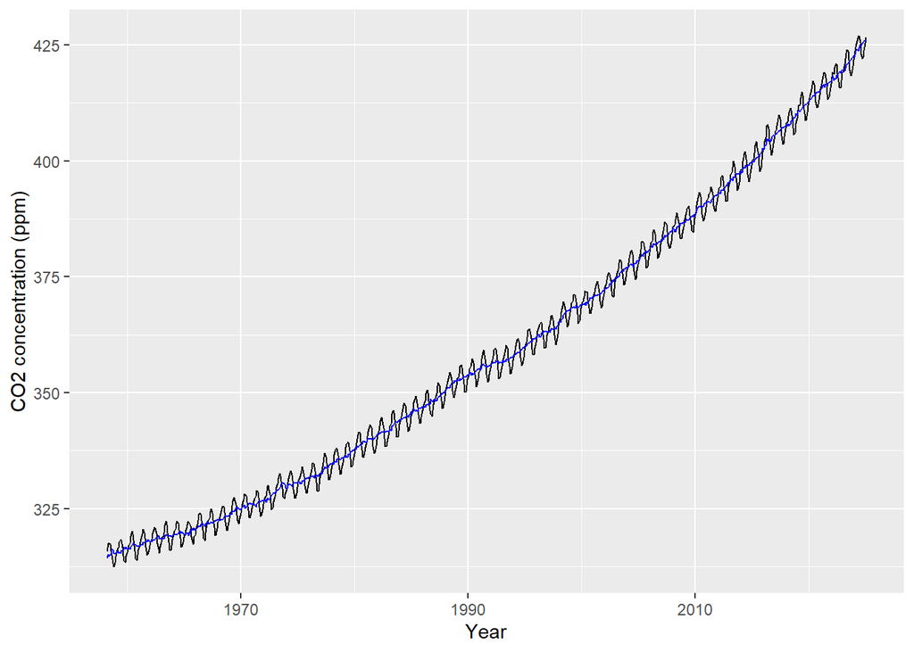

```r
ggplot(co2, aes(x = decimal_date, y = monthly_average)) +
  geom_line() +
  geom_line(aes(y = deseasonalized), color = "blue") +
  labs(x = "Year", y = "CO2 concentration (ppm)")
```

**Question 1:**

Describe the overall trend in the CO2 data.

**Answer 1:** The CO2 concentration in the atmosphere has been increasing every year since 1958. By the slight curve of the line, it appears that it is increasing exponentially.

**Question 2:**

How does CO2 vary within a year? What month is it at max? Min? What might explain this sub-annual pattern? (you will need to write code and make a plot to answer this question)

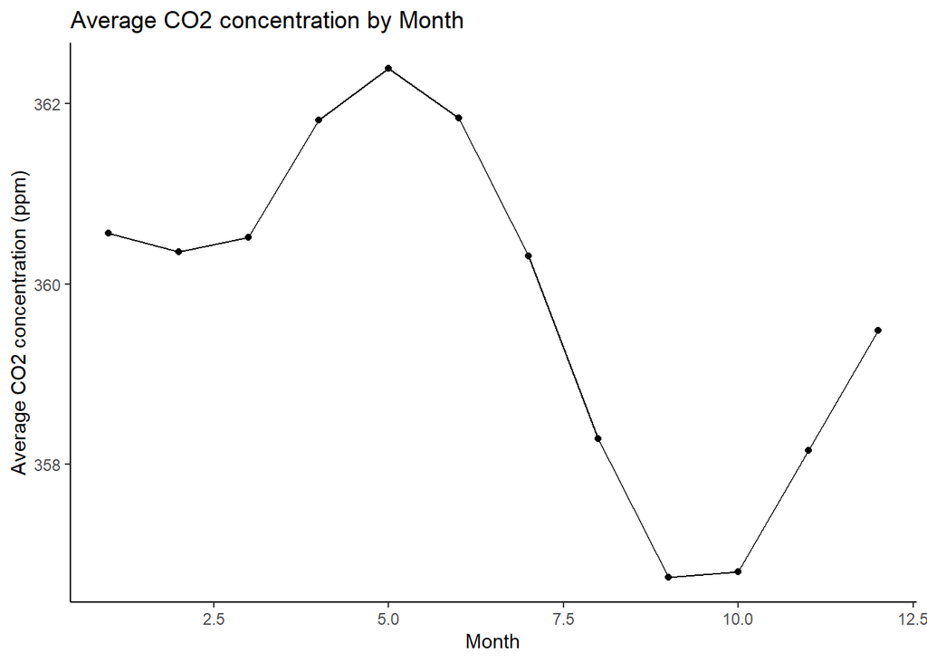

```r
co2 |> #groups the co2 tables by month, creates a mean CO2 concentration for a month using the existing monthly average, and plots it.
  group_by(month) |>
  summarize(monthly_avg = mean(monthly_average)) |>
  ggplot(aes(x = month, y = monthly_avg)) +
  geom_line() +
  geom_point() +
  labs(x = "Month",
       y = "Average CO2 concentration (ppm)",
       title = "Average CO2 concentration by Month") +
  theme_classic()
```

## Global Temperature Data

Current climate change affects many aspects of the environment, with socio-economic consequences. For example, a warmer climate can allow new diseases to be introduced and persist (e.g., West Nile became established in the United States after an unusually warm winter, which allowed the mosquitoes that carry the virus to survive and spread). We are concerned not only with the actual temperature but also with the rate at which it changes. Rapid changes make it more likely that species cannot adapt and will go extinct.

Each of the most recent years has been the warmest on record. In this section, we will analyze global mean temperature data.

Data from: https://climate.nasa.gov/vital-signs/global-temperature/

**Question 3:**

Describe the data set to the best of your ability, given the documentation provided.

- Where is the data from?
- Describe the class of each column and what units it is measured in.
- What is the difference between “global temperature” and “global temperature anomaly”?

**Answer 3:** The data comes from NASA/GISS, or the Goddard Institute for Space Studies. The Year column in the data set is a numeric, specifically an integer. No_Smoothing is a numeric double, and its units are Celsius. Based on the graph, No_Smoothing is the annual mean. Lowess(5) is also a double with units of Celsius, and it is sort of like a line of best fit. Global temperature is the actual measured temperature, whereas a global temperature anomaly is the difference between the measured temperature and the average, or baseline, temperature over a period of time.

**Question 4:**

Construct the necessary R code to import and prepare for plotting the following data set: https://data.giss.nasa.gov/gistemp/graphs/graph_data/Global_Mean_Estimates_based_on_Land_and_Ocean_Data/graph.txt

You’ll need to determine the file’s delimiter and any comments or skips. You will also need to be sure that you have column names. You will not directly use the code above to read the CO2 data, but that code provides helpful tips for reading the data.

**Answer 4:**

```r
global_temp <- read_table(
  "https://data.giss.nasa.gov/gistemp/graphs/graph_data/Global_Mean_Estimates_based_on_Land_and_Ocean_Data/graph.txt",
  col_names = c("Year", "Mean_Temp", "Lowess"),
  skip = 5
) #Reads in the global temperature data, skips the first 5 lines and then re-adds the headers, renamed to be similar to NASA's graph.
```

**Question 5:**

Plot the trend in global mean temperatures over time. Describe what you see in the plot and how you interpret the patterns you observe.

**Answer 5:**

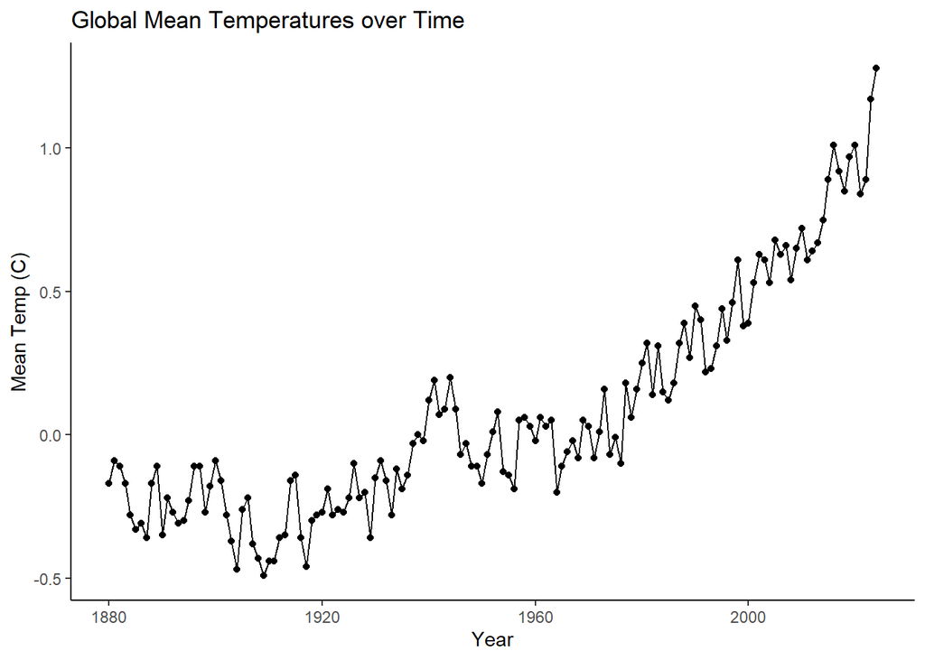

```r
global_temp |>
  ggplot(aes(x = Year, y = Mean_Temp)) +
  geom_point() +
  geom_line() +
  labs(x = "Year", y = "Mean Temp (C)",
       title = "Global Mean Temperatures over Time") +
  theme_classic()
```

The mean global temperature is on a generally upwards trend, but it fluctuates year to year. There was a large spike in the 1940s, which seems to indicate that global temperature rose during World War 2, perhaps due to a massive increase in manufacturing, or higher amounts of combustion. The reason for the year to year fluctuation may be caused by the fact that there are countless influences on global temperature.

## Evaluating the evidence for a “Pause” in warming?

The [2013 IPCC Report](https://www.ipcc.ch/pdf/assessment-report/ar5/wg1/WG1AR5_SummaryVolume_FINAL.pdf) included a tentative observation of a “much smaller increasing trend” in global mean temperatures since 1998 than was observed previously. This led to much discussion in the media about the existence of a “Pause” or “Hiatus” in global warming rates, as well as much research looking into where the extra heat could have gone. (Examples discussing this question include articles in [The Guardian](http://www.theguardian.com/environment/2015/jun/04/global-warming-hasnt-paused-study-finds), [BBC News](http://www.bbc.com/news/science-environment-28870988), and [Wikipedia](https://en.wikipedia.org/wiki/Global_warming_hiatus)).

You will use rolling averages to help you explore the evidence for a pause. Since you have not been provided instructions for calculating rolling means, the learning objective of this question is to practice finding the solution.

**Question 6:**

Use a search engine (e.g., Google) or a chat LLM to find out how to calculate a rolling average in R. What search term or chat LLM prompt did you use? What website or answer from the chat LLM did you end up using? How much did you need to modify the code from the website or chat LLM to answer the question successfully?

**Answer 6:** I asked ChatGPT and Google the same question, “How to calculate rolling average in R?” and both told me to install the library zoo, which includes a rollmean function.

**Question 7:**

- What is the meaning of “5-year average” vs. “annual average”?
- Create a data frame from the annual temperature anomaly data (from Question 4) with three new columns: 5-year running averages, 10-year running averages, and 20-year running averages.

**Answer 7:** A 5-year average is a rolling average over the past 5 years, while an annual average is just the mean of a single year.

```r
library(zoo)
global_temp <- global_temp |> #5 year rolling average, using right align.
  mutate("Five_Year_Avg" = rollmean(Mean_Temp, k = 5, fill = NA, align = "right")) |>
  mutate("Ten_Year_Avg" = rollmean(Mean_Temp, k = 10, fill = NA, align = "right")) |>
  mutate("Twenty_Year_Avg" = rollmean(Mean_Temp, k = 20, fill = NA, align = "right"))
```

**Question 8:**

Plot the different averages on the *same plot* and describe what differences you see and why.

**Answer 8:**

[figure not shown]

```r
global_temp |>
  ggplot(aes(x = Year)) +
  geom_line(aes(y = Five_Year_Avg, color = "blue")) +
  geom_line(aes(y = Ten_Year_Avg, color = "red")) +
  geom_line(aes(y = Twenty_Year_Avg, color = "green")) +
  scale_color_manual(labels = c("Five Year Average", "Ten Year Average", "Twenty Year Average"),
                     values = c("blue", "red", "green"))+
  labs(x = "Year",
       y = "Rolling average temperature (C)",
       title = "Comparing rolling average mean temperatures by year") +
  theme_classic()
```

**Question 9:**

By examining the data here, what evidence do you find or not find for such a pause?

## Longer term trends in CO2 Records

When analyzing Earth’s climate, it is important to remember that Earth is 4.54 billion years old. Our analyses so far have only looked at recent history. How can we compare the recent data to prehistoric times? Are the current rates of change similar or different from those the earth has experienced in the past? To explore this, we can use data from ice cores drilled at the poles.

Hundreds of ice cores have been extracted from polar ice because they contain valuable data on atmospheric chemistry over pre-historic times. These valuable data exist in tiny air bubbles trapped in the ice. These air bubbles contain the same gases in the same ratios as the atmosphere at the time when the ice formed. The data you will analyze today are from ice cores extracted from the Vostok research station in Antarctica. As you have probably assumed, the depth of the ice core is related to how old the ice is; deep ice is older. There are two other variables that you will be analyzing from the ice cores. You will analyze CO2 concentration, which has been measured from air bubbles trapped in the ice. We can use these data to see what rates of change were like during this pre-historic period, during which human activity was minimal.

[Ice core data](https://data.ess-dive.lbl.gov/view/doi%3A10.3334%2FCDIAC%2FATG.009):

Vostok Core, back to 400,000 years before the present day

- Description of data set: https://data.ess-dive.lbl.gov/view/doi%3A10.3334%2FCDIAC%2FATG.009
- data: https://data.ess-dive.lbl.gov/catalog/d1/mn/v2/object/ess-dive-457358fdc81d3a5-20180726T203952542

You will use this code to download the data to your computer.

```r
download.file("https://data.ess-dive.lbl.gov/catalog/d1/mn/v2/object/ess-dive-457358fdc81d3a5-20180726T203952542",
              destfile = "vostok.icecore.co2")
```

You can click on the file in your Files pane to view it before reading into R.

**Question 10:**

The broad question is: how do recent atmospheric CO2 levels compare to historical levels?

Your answer to Question 10 is going to be a mix of code chunks and text that you put below in “Answer 10:”

- Describe the data set: what are the columns and units? Where do the numbers come from?
- What is the temporal resolution of the data?
- Read in and prepare data for analysis.
- Reverse the ordering to create a chronological record so that each measurement is associcated with calender year.
- Plot data.
- Combine this time series with the Mauna Loa data (the Warm-up exercise in this assignment). You will use “bind_rows()”.
- Plot the combined data. (the most recent time period must be on the right side of the plot).
- Describe your conclusions to the question “How do recent atmospheric CO2 levels compare to historical levels?” using your plot as supporting evidence.

**Answer 10:** The columns and units are: Depth in meters, Age of the ice in years (before present), mean age of the air in years (before present) and the CO2 concentration in the air in parts per million. The temporal resolution of the data is not consistent, ranging between 2000 years between measurements and 200 years.

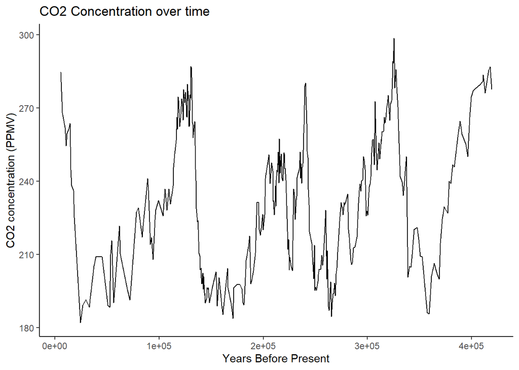

```r
ice_core_CO2 <- read_table("vostok.icecore.co2", skip = 21, col_names = c("Depth", "Age_Ice", "Mean_Age_Air", "CO2")) |>
  arrange(desc(Age_Ice)) |>
  mutate(year = (2003 - Age_Ice)) #Included year to represent the year in BC/BCE by subtracting Age (BP) from the year 2003.
ice_core_CO2 |>
  ggplot(aes(x = Age_Ice, y = CO2)) +
  geom_line() +
  theme_classic() +
  labs(x = "Years Before Present", y = "CO2 concentration (PPMV)", title = "CO2 Concentration over time")
```

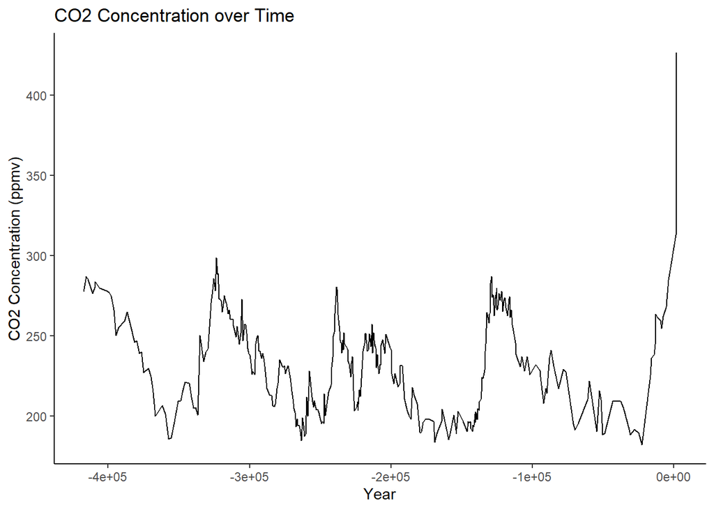

```r
co2 <- co2 |> group_by(year) |>
  mutate(CO2 = mean(monthly_average)) #creates a yearly average for the original CO2 dateframe to more easily combine the two
co2_comp <- bind_rows(co2, ice_core_CO2)

co2_comp |>
  ggplot(aes(x = year, y = CO2)) +
  geom_line() +
  theme_classic() +
  labs(x = "Year", y = "CO2 Concentration (ppmv)", title = "CO2 Concentration over Time")
```

Remember to Render your document as HTML and comment+push to GitHub your code and rendered HTML that was created when you knitted the document. Your GitHub repository should have multiple commits with informative commit messages.

# Attribution

Include citation of any AI-generated assistance or discussion with classmates (per policy in syllabus). Proper documentation of AI-generated assistance includes the prompt, the source (e.g., ChatGPT), and the significant parts of the response. Proper documentation of discussion with classmates include listing their names and the components discussed.

Per question 6, I asked chatgpt “how to calculate a rolling average in R?” The important parts of its response are as follows: 1. Install and load the “zoo” package library(zoo) 3. Calculate the rolling average: rolling_average <- rollmean(data, k = 3, fill = NA)

k: the window size for the rolling average.

The parts omitted from the response were for creating a dataframe and alignment, the latter of which was answered using ?rollmean().